# Projet Mathématiques pour le Big Data — Optimisation, Pseudo-inverse, ACP, AFC

ESGI 5A BD

2026-03-30

# 1 Exercice 1 — Moindres carrés

## 1.1 Données et transformation logarithmique

On dispose des données suivantes sur la revente d’un article :

```r
t <- c(0, 1, 2, 3, 4, 5, 6)
Xt <- c(90, 73.8, 60, 49.5, 40.5, 33, 27)
n <- length(t)

# Affichage du tableau
knitr::kable(data.frame(t = t, Xt = Xt),
             col.names = c("t (années)", "Xt (centaines €)"),
             caption = "Prix de revente en fonction du temps")
```

Prix de revente en fonction du temps

| t (années) | Xt (centaines €) |
| --- | --- |
| 0 | 90.0 |
| 1 | 73.8 |
| 2 | 60.0 |
| 3 | 49.5 |
| 4 | 40.5 |
| 5 | 33.0 |
| 6 | 27.0 |

```r
# Transformation logarithmique
Zt <- log(Xt)
cat("Valeurs de Zt = ln(Xt) :\n")
```

```
## Valeurs de Zt = ln(Xt) :
```

```r
print(round(Zt, 4))
```

```
## [1] 4.4998 4.3014 4.0943 3.9020 3.7013 3.4965 3.2958
```

## 1.2 Droite d’ajustement par les moindres carrés

On cherche $Z_t = at + b$ par la méthode des moindres carrés (sans fonction prédéfinie).

```r
# Moyennes
t_bar <- sum(t) / n
Z_bar <- sum(Zt) / n

# Pente a = Cov(t,Z) / Var(t)
cov_tZ <- sum((t - t_bar) * (Zt - Z_bar))
var_t  <- sum((t - t_bar)^2)
a <- cov_tZ / var_t

# Ordonnée à l'origine
b <- Z_bar - a * t_bar

cat("Pente a =", round(a, 6), "\n")
```

```
## Pente a = -0.200524
```

```r
cat("Ordonnée à l'origine b =", round(b, 6), "\n")
```

```
## Ordonnée à l'origine b = 4.500304
```

```r
cat("Droite d'ajustement : Z(t) =", round(a, 4), "× t +", round(b, 4), "\n")
```

```
## Droite d'ajustement : Z(t) = -0.2005 × t + 4.5003
```

## 1.3 Ajustement exponentiel

Puisque $Z_t = \ln(X_t) = at + b$, on en déduit $X_t = e^{at+b} = e^b \cdot e^{at}$.

```r
A_coeff <- exp(b)
cat("Modèle exponentiel : X(t) =", round(A_coeff, 4), "× exp(", round(a, 4), "× t)\n")
```

```
## Modèle exponentiel : X(t) = 90.0445 × exp( -0.2005 × t)
```

```r
# Estimation à t = 10
t10 <- 10
X10 <- exp(a * t10 + b)
cat("Estimation à t = 10 ans :", round(X10, 2), "centaines d'euros\n")
```

```
## Estimation à t = 10 ans : 12.12 centaines d'euros
```

```r
cat("Soit environ", round(X10 * 100, 0), "euros\n")
```

```
## Soit environ 1212 euros
```

## 1.4 Graphiques

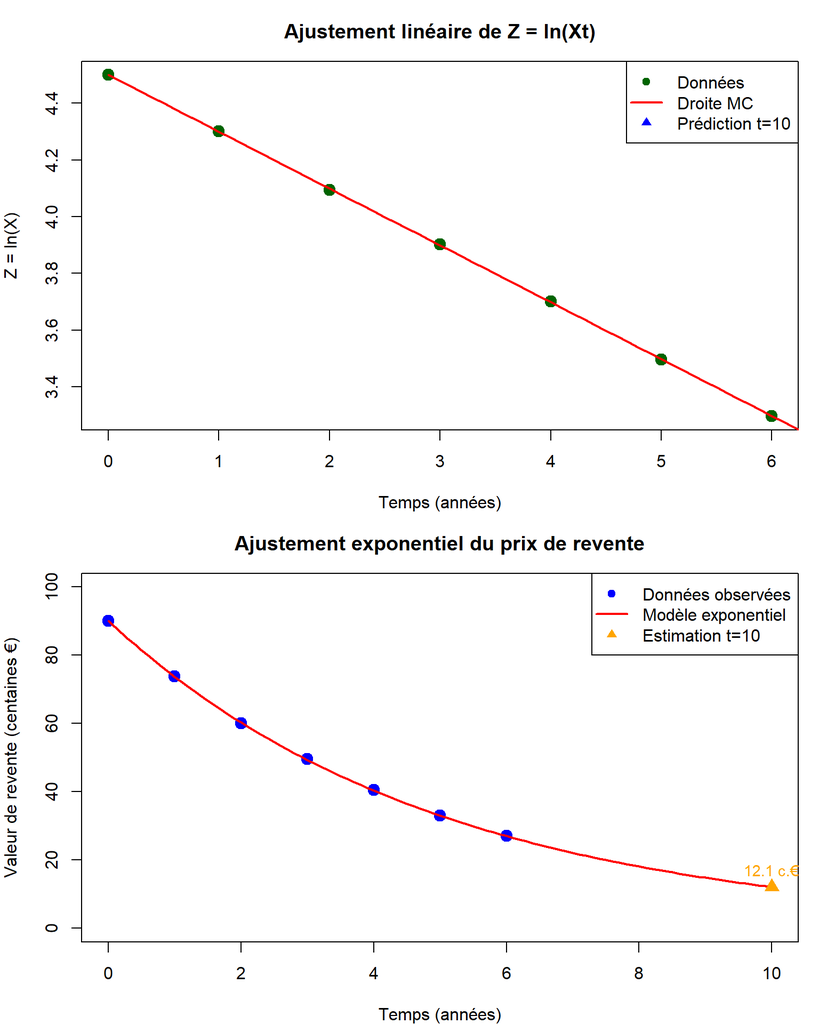

```r
par(mfrow = c(2, 1), mar = c(4, 4, 3, 1))

# Graphique 1 : Ajustement linéaire sur Z = ln(X)
plot(t, Zt, pch = 19, col = "darkgreen", cex = 1.5,
     xlab = "Temps (années)", ylab = "Z = ln(X)",
     main = "Ajustement linéaire de Z = ln(Xt)")
t_seq <- seq(0, 10, 0.1)
lines(t_seq, a * t_seq + b, col = "red", lwd = 2)
abline(v = 10, lty = 3, col = "gray")
points(10, a*10 + b, pch = 17, col = "blue", cex = 1.5)
legend("topright",
       legend = c("Données", "Droite MC", "Prédiction t=10"),
       col = c("darkgreen", "red", "blue"),
       pch = c(19, NA, 17), lwd = c(NA, 2, NA))

# Graphique 2 : Ajustement exponentiel
plot(t, Xt, pch = 19, col = "blue", cex = 1.5,
     xlab = "Temps (années)", ylab = "Valeur de revente (centaines €)",
     main = "Ajustement exponentiel du prix de revente",
     xlim = c(0, 10), ylim = c(0, 100))
lines(t_seq, A_coeff * exp(a * t_seq), col = "red", lwd = 2)
points(10, X10, pch = 17, col = "orange", cex = 1.5)
text(10, X10 + 5, paste0(round(X10, 1), " c.€"), col = "orange", cex = 0.9)
legend("topright",
       legend = c("Données observées", "Modèle exponentiel", "Estimation t=10"),
       col = c("blue", "red", "orange"),
       pch = c(19, NA, 17), lwd = c(NA, 2, NA))
```

```r
par(mfrow = c(1, 1))
```

**Interprétation :** Le modèle exponentiel $X(t) = 90.04 \times e^{-0.2005 t}$ ajuste très bien les données. La valeur de revente estimée à 10 ans est d’environ **12.1 centaines d’euros**, soit 1212 €.

# 2 Exercice 2 — Optimisation sans contrainte

## 2.1 Exercice 2.2.1 : $f(x,y) = e^{xy} - e^x + 2$

### 2.1.1 Recherche des points critiques

```r
# Définition de f
f1 <- function(x, y) exp(x * y) - exp(x) + 2

# Gradient de f
# df/dx = y*exp(xy) - exp(x)
# df/dy = x*exp(xy)
# df/dy = 0 => x = 0 (car exp(xy) != 0)
# df/dx = 0 avec x=0 => y*exp(0) - exp(0) = 0 => y - 1 = 0 => y = 1

cat("Résolution analytique du gradient = 0 :\n")
```

```
## Résolution analytique du gradient = 0 :
```

```r
cat("  df/dy = x*exp(xy) = 0  =>  x = 0\n")
```

```
##   df/dy = x*exp(xy) = 0  =>  x = 0
```

```r
cat("  df/dx = y*exp(xy) - exp(x) = 0  avec x=0  =>  y - 1 = 0  =>  y = 1\n\n")
```

```
##   df/dx = y*exp(xy) - exp(x) = 0  avec x=0  =>  y - 1 = 0  =>  y = 1
```

```r
x0 <- 0; y0 <- 1
cat("Point critique unique : (", x0, ",", y0, ")\n")
```

```
## Point critique unique : ( 0 , 1 )
```

```r
cat("Valeur de f(0,1) =", f1(x0, y0), "\n")
```

```
## Valeur de f(0,1) = 2
```

### 2.1.2 Matrice hessienne et nature du point

```r
# Hessienne analytique :
# d²f/dx² = y²*exp(xy) - exp(x)
# d²f/dxdy = exp(xy) + xy*exp(xy)
# d²f/dy² = x²*exp(xy)

H1 <- matrix(c(
  y0^2 * exp(x0*y0) - exp(x0),   exp(x0*y0) + x0*y0*exp(x0*y0),
  exp(x0*y0) + x0*y0*exp(x0*y0), x0^2 * exp(x0*y0)
), nrow = 2, byrow = TRUE)

cat("Hessienne en (0,1) :\n")
```

```
## Hessienne en (0,1) :
```

```r
print(H1)
```

```
##      [,1] [,2]
## [1,]    0    1
## [2,]    1    0
```

```r
vp1 <- eigen(H1)$values
cat("\nValeurs propres :", round(vp1, 6), "\n")
```

```
##
## Valeurs propres : 1 -1
```

```r
if (all(vp1 > 0)) {
  cat("=> Hessienne définie positive : MINIMUM LOCAL\n")
} else if (all(vp1 < 0)) {
  cat("=> Hessienne définie négative : MAXIMUM LOCAL\n")
} else {
  cat("=> Hessienne indéfinie : POINT SELLE\n")
}
```

```
## => Hessienne indéfinie : POINT SELLE
```

### 2.1.3 Tracé sur $[0,2]^2$

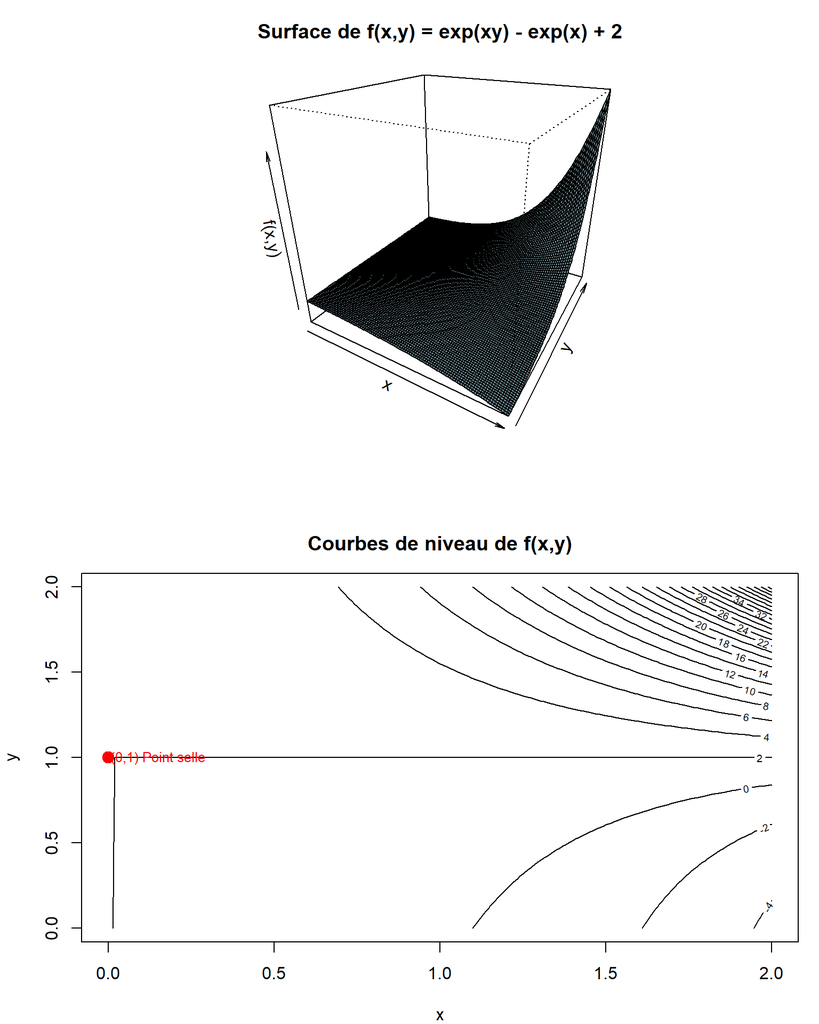

```r
x_grid <- seq(0, 2, length.out = 100)
y_grid <- seq(0, 2, length.out = 100)
z_grid <- outer(x_grid, y_grid, f1)

par(mfrow = c(2, 1), mar = c(4, 4, 3, 1))

# Surface 3D
persp(x_grid, y_grid, z_grid,
      theta = 30, phi = 25, col = "lightblue", shade = 0.4,
      xlab = "x", ylab = "y", zlab = "f(x,y)",
      main = "Surface de f(x,y) = exp(xy) - exp(x) + 2")

# Courbes de niveau
contour(x_grid, y_grid, z_grid, nlevels = 25,
        xlab = "x", ylab = "y",
        main = "Courbes de niveau de f(x,y)")
points(x0, y0, pch = 19, col = "red", cex = 1.5)
text(x0 + 0.15, y0, "(0,1) Point selle", col = "red", cex = 0.8)
```

```r
par(mfrow = c(1, 1))
```

**Conclusion :** La Hessienne en $(0,1)$ est indéfinie (valeurs propres de signes opposés), donc $(0,1)$ est un **point selle**.

## 2.2 Exercice 2.2.2 : $g(x,y,z) = (x + z^2)e^{x(y^2 + z^2 + 1)}$

```r
g_func <- function(x, y, z) (x + z^2) * exp(x * (y^2 + z^2 + 1))

cat("Recherche des points critiques de g(x,y,z):\n\n")
```

```
## Recherche des points critiques de g(x,y,z):
```

```r
cat("dg/dy = 2xy(x+z²)exp(x(y²+z²+1)) = 0\n")
```

```
## dg/dy = 2xy(x+z²)exp(x(y²+z²+1)) = 0
```

```r
cat("dg/dz = [2z + 2xz(x+z²)]exp(x(y²+z²+1)) = 0\n")
```

```
## dg/dz = [2z + 2xz(x+z²)]exp(x(y²+z²+1)) = 0
```

```r
cat("dg/dx = [1 + (x+z²)(y²+z²+1)]exp(x(y²+z²+1)) = 0\n\n")
```

```
## dg/dx = [1 + (x+z²)(y²+z²+1)]exp(x(y²+z²+1)) = 0
```

```r
cat("Analyse:\n")
```

```
## Analyse:
```

```r
cat("- dg/dy = 0 avec exp(...) > 0 => 2xy(x+z²) = 0\n")
```

```
## - dg/dy = 0 avec exp(...) > 0 => 2xy(x+z²) = 0
```

```r
cat("- Si y = 0 et z = 0, alors dg/dx = [1 + x]exp(x) = 0 => x = -1\n\n")
```

```
## - Si y = 0 et z = 0, alors dg/dx = [1 + x]exp(x) = 0 => x = -1
```

```r
x0 <- -1; y0 <- 0; z0 <- 0
cat("Point critique : (", x0, ",", y0, ",", z0, ")\n")
```

```
## Point critique : ( -1 , 0 , 0 )
```

```r
cat("g(-1,0,0) =", g_func(x0, y0, z0), "\n\n")
```

```
## g(-1,0,0) = -0.3678794
```

```r
# Vérification : gradient en (-1,0,0)
E <- exp(-1)
# dg/dx en (-1,0,0) : [1 + (-1+0)*(0+0+1)]*exp(-1) = [1-1]*exp(-1) = 0 ✓
# dg/dy en (-1,0,0) : 2*(-1)*0*(-1+0)*exp(-1) = 0 ✓
# dg/dz en (-1,0,0) : [0 + 0]*exp(-1) = 0 ✓

# Hessienne en (-1,0,0), calculée analytiquement :
H2 <- exp(-1) * matrix(c(
  1, 0, 0,
  0, 2, 0,
  0, 0, 4
), nrow = 3, byrow = TRUE)

cat("Hessienne en (-1,0,0) :\n")
```

```
## Hessienne en (-1,0,0) :
```

```r
print(round(H2, 6))
```

```
##          [,1]     [,2]     [,3]
## [1,] 0.367879 0.000000 0.000000
## [2,] 0.000000 0.735759 0.000000
## [3,] 0.000000 0.000000 1.471518
```

```r
vp2 <- eigen(H2)$values
cat("\nValeurs propres :", round(vp2, 6), "\n")
```

```
##
## Valeurs propres : 1.471518 0.735759 0.367879
```

```r
if (all(vp2 > 0)) {
  cat("=> Hessienne définie positive : MINIMUM LOCAL\n")
  cat("=> g(-1,0,0) =", round(g_func(x0, y0, z0), 6), "est un minimum local\n")
} else if (all(vp2 < 0)) {
  cat("=> MAXIMUM LOCAL\n")
} else {
  cat("=> POINT SELLE\n")
}
```

```
## => Hessienne définie positive : MINIMUM LOCAL
## => g(-1,0,0) = -0.367879 est un minimum local
```

**Conclusion :** Toutes les valeurs propres de la Hessienne sont positives, donc $(-1, 0, 0)$ est un **minimum local** avec $g(-1,0,0) = -e^{-1} \approx -0.368$.

## 2.3 Exercice 2.2.3 : $h(x,y,z) = \ln(xyz) - \ln(x)\ln(y)\ln(z)$ sur $]0,+\infty[^3$

```r
h_func <- function(x, y, z) log(x*y*z) - log(x)*log(y)*log(z)

cat("Gradient de h :\n")
```

```
## Gradient de h :
```

```r
cat("dh/dx = (1 - ln(y)ln(z)) / x\n")
```

```
## dh/dx = (1 - ln(y)ln(z)) / x
```

```r
cat("dh/dy = (1 - ln(x)ln(z)) / y\n")
```

```
## dh/dy = (1 - ln(x)ln(z)) / y
```

```r
cat("dh/dz = (1 - ln(x)ln(y)) / z\n\n")
```

```
## dh/dz = (1 - ln(x)ln(y)) / z
```

```r
cat("Points critiques : dh/dx = dh/dy = dh/dz = 0\n")
```

```
## Points critiques : dh/dx = dh/dy = dh/dz = 0
```

```r
cat("=> 1 - ln(y)ln(z) = 0, 1 - ln(x)ln(z) = 0, 1 - ln(x)ln(y) = 0\n")
```

```
## => 1 - ln(y)ln(z) = 0, 1 - ln(x)ln(z) = 0, 1 - ln(x)ln(y) = 0
```

```r
cat("Par symétrie : ln(x) = ln(y) = ln(z) = c\n")
```

```
## Par symétrie : ln(x) = ln(y) = ln(z) = c
```

```r
cat("=> c² = 1  =>  c = 1 ou c = -1\n")
```

```
## => c² = 1  =>  c = 1 ou c = -1
```

```r
cat("=> (e, e, e) ou (1/e, 1/e, 1/e)\n\n")
```

```
## => (e, e, e) ou (1/e, 1/e, 1/e)
```

```r
# Point critique 1 : (e, e, e)
cat("===== Point critique 1 : (e, e, e) =====\n")
```

```
## ===== Point critique 1 : (e, e, e) =====
```

```r
x1 <- exp(1); y1 <- exp(1); z1 <- exp(1)
cat("h(e,e,e) =", h_func(x1, y1, z1), "\n\n")
```

```
## h(e,e,e) = 2
```

```r
# Hessienne en (e,e,e)
# d²h/dx² = -(1 - ln(y)ln(z))/x² = 0/e² = 0
# d²h/dxdy = -ln(z)/(xy) = -1/e²
H_eee <- matrix(c(
  0,         -1/exp(2), -1/exp(2),
  -1/exp(2),  0,        -1/exp(2),
  -1/exp(2), -1/exp(2),  0
), nrow = 3, byrow = TRUE)

cat("Hessienne en (e,e,e) :\n")
```

```
## Hessienne en (e,e,e) :
```

```r
print(round(H_eee, 6))
```

```
##           [,1]      [,2]      [,3]
## [1,]  0.000000 -0.135335 -0.135335
## [2,] -0.135335  0.000000 -0.135335
## [3,] -0.135335 -0.135335  0.000000
```

```r
vp_eee <- eigen(H_eee)$values
cat("\nValeurs propres :", round(vp_eee, 6), "\n")
```

```
##
## Valeurs propres : 0.135335 0.135335 -0.270671
```

```r
if (any(vp_eee > 1e-10) && any(vp_eee < -1e-10)) {
  cat("=> Hessienne indéfinie : POINT SELLE\n")
}
```

```
## => Hessienne indéfinie : POINT SELLE
```

```r
# Point critique 2 : (1/e, 1/e, 1/e)
cat("\n===== Point critique 2 : (1/e, 1/e, 1/e) =====\n")
```

```
##
## ===== Point critique 2 : (1/e, 1/e, 1/e) =====
```

```r
x2 <- exp(-1); y2 <- exp(-1); z2 <- exp(-1)
cat("h(1/e,1/e,1/e) =", h_func(x2, y2, z2), "\n\n")
```

```
## h(1/e,1/e,1/e) = -2
```

```r
H_inv <- matrix(c(
  0,        exp(2), exp(2),
  exp(2),   0,      exp(2),
  exp(2),   exp(2), 0
), nrow = 3, byrow = TRUE)

cat("Hessienne en (1/e,1/e,1/e) :\n")
```

```
## Hessienne en (1/e,1/e,1/e) :
```

```r
print(round(H_inv, 6))
```

```
##          [,1]     [,2]     [,3]
## [1,] 0.000000 7.389056 7.389056
## [2,] 7.389056 0.000000 7.389056
## [3,] 7.389056 7.389056 0.000000
```

```r
vp_inv <- eigen(H_inv)$values
cat("\nValeurs propres :", round(vp_inv, 6), "\n")
```

```
##
## Valeurs propres : 14.77811 -7.389056 -7.389056
```

```r
if (any(vp_inv > 1e-10) && any(vp_inv < -1e-10)) {
  cat("=> Hessienne indéfinie : POINT SELLE\n")
}
```

```
## => Hessienne indéfinie : POINT SELLE
```

**Conclusion :** Les deux points critiques $(e, e, e)$ et $(1/e, 1/e, 1/e)$ sont des **points selles**. La fonction $h$ n’admet pas d’extremum local sur $]0,+\infty[^3$.